# Day 3 — The Finite Element Method

*Prof. Peter Bastian, slides 56–76. This notebook follows the lecture slide by slide, in plain language, with runnable code for every step.*

### Plan for the lecture (slide 57)

1. Get to know the **Finite Element Method (FEM)**, a numerical solution technique
2. Understand how the corresponding **linear system $A\mathbf{z} = \mathbf{b}$** is set up
3. Understand the **convergence properties** of FEM

### My notes from class

```
# Day 3 — From weak formulation to a linear system

Analytic solutions of PDEs require strong simplifications. Linear second-order elliptic PDEs can often be
solved by separation of variables, Fourier series, or Green's functions — but only on simple geometries.
For complex geometries or boundary conditions we use numerical methods: finite differences, finite
elements, or spectral methods.

**Recap from yesterday**

1. **Strong formulation** — the PDE holds pointwise; needs $u \in C^2$.
2. **Weak formulation** — multiply by a test function $v$, integrate, and integrate by parts to move one
   derivative onto $v$. Needs only $u \in H^1$.

$$\text{find } u \in V: \qquad a(u,v) = \ell(v) \quad \forall v \in V,
\qquad a(u,v) = \int_\Omega \nabla u\cdot\nabla v\,dx, \quad \ell(v) = \int_\Omega f v\,dx$$

For **finite-dimensional methods** the weak formulation is the one we discretise: it needs only first
derivatives (so piecewise-linear functions are admissible), and it turns directly into a linear system.

### What is span?

Given functions $\varphi_1, \dots, \varphi_N$, their **span** is the set of all linear combinations

$$V_h = \operatorname{span}\{\varphi_1,\dots,\varphi_N\} = \Big\{ v = \sum_{j=1}^{N} v_j \varphi_j : v_j \in \mathbb{R} \Big\}$$

- the span is a **vector space** (the set of reachable functions), not a number;
- if the $\varphi_j$ are **linearly independent** they are a *basis* and $\dim V_h = N$;
- the coefficients $(v_1,\dots,v_N)$ are coordinates — this is how a function becomes a vector in $\mathbb{R}^N$.

### Galerkin: a span turns the PDE into a matrix equation

Replace the infinite-dimensional $V$ by $V_h = \operatorname{span}\{\varphi_1,\dots,\varphi_N\} \subset V$:

$$\text{find } u_h \in V_h: \qquad a(u_h, v_h) = \ell(v_h) \quad \forall v_h \in V_h$$

Insert $u_h = \sum_j u_j \varphi_j$ and test with each $\varphi_i$ (enough, by linearity):

$$\sum_{j=1}^N \underbrace{a(\varphi_j, \varphi_i)}_{A_{ij}\ \text{stiffness matrix}} u_j
= \underbrace{\ell(\varphi_i)}_{b_i\ \text{load vector}} \qquad\Longleftrightarrow\qquad A\mathbf{u} = \mathbf{b}$$

The choice of basis is what names the method:

| basis $\varphi_j$ | support | method |
|---|---|---|
| hat functions on a mesh | local (2 elements) | **finite elements** — sparse $A$, any geometry |
| $\sin(j\pi x)$, polynomials | global | **spectral** — dense $A$, spectacular accuracy, simple domains only |
```

## 1. Motivation (slide 58)

**The problem:** analytic solutions of PDEs require strong simplifications — separation of variables, Fourier series and Green's functions only work on simple domains with simple data. Real problems have neither.

**The answer:** compute the solution numerically. Three families:

| method | idea | where it shines |
| --- | --- | --- |
| Finite Difference (FDM) | replace derivatives by difference quotients on a grid | simple, fast, needs a structured grid |
| Finite Volume (FVM) | conservation law on small control volumes | conservation is exact; flow problems |
| **Finite Element (FEM)** | weak form on a finite-dimensional subspace | complex geometry, theory, generality |

**Why the course focuses on FEM:**

- very flexible with respect to **geometry and data** of the PDE,
- handles linear/nonlinear, stationary/instationary, scalar/system cases,
- has a **well-developed convergence theory** (we can prove how fast it converges),
- many mature open-source packages exist.

## 2. Recap: how a PDE becomes a matrix (slide 59)

**Strong formulation** — the homogeneous Dirichlet problem:

$$-\nabla\cdot(A\nabla u) = f \quad\text{in }\Omega \subseteq \mathbb{R}^d,\ d = 2,3 \qquad u = 0 \ \text{ on } \partial\Omega$$

**Weak formulation** in $V = H^1_0(\Omega)$ — multiply by a test function, integrate, integrate by parts:

$$\text{Find } u \in V: \qquad \underbrace{\int_\Omega (A\nabla u)\cdot\nabla v \,dx}_{a(u,v)} = \underbrace{\int_\Omega f v\,dx}_{\ell(v)} \qquad \forall v \in V$$

**Finite-dimensional subspace.** $V$ is infinite-dimensional — a computer cannot store it. So pick

$$V_h = \operatorname{span}\{\varphi_1,\dots,\varphi_N\} \subset V$$

> **What is span?** The span of $\varphi_1,\dots,\varphi_N$ is the set of *all their linear combinations*, $\big\{\sum_j z_j\varphi_j\big\}$ — a **vector space**, not a number. If the $\varphi_j$ are linearly independent they form a **basis** and $N = \dim V_h$. The coefficients $(z_1,\dots,z_N)$ are coordinates: this is how a *function* becomes a *vector* a computer can hold.

Represent $u_h = \sum_{j=1}^N z_j \varphi_j$ and insert it into the weak formulation. Because $a$ is linear in both arguments, testing against every $v \in V_h$ is the same as testing against each basis function $\varphi_i$:

$$a\Big(\sum_{j=1}^N z_j\varphi_j,\ v\Big) = \ell(v)\ \forall v \in V_h \iff \sum_{j=1}^N z_j\, a(\varphi_j,\varphi_i) = \ell(\varphi_i)\ \forall i = 1,\dots,N$$

$$\iff \boxed{A\mathbf{z} = \mathbf{b}, \qquad (A)_{i,j} = a(\varphi_j,\varphi_i), \qquad (b)_i = \ell(\varphi_i)}$$

**That is the whole idea of FEM.** Everything that follows is about *how to choose the $\varphi_i$ and how to compute those integrals.*

```python
import numpy as np
import matplotlib.pyplot as plt
import matplotlib.tri as mtri
import scipy.sparse as sp
import scipy.sparse.linalg as spla
```

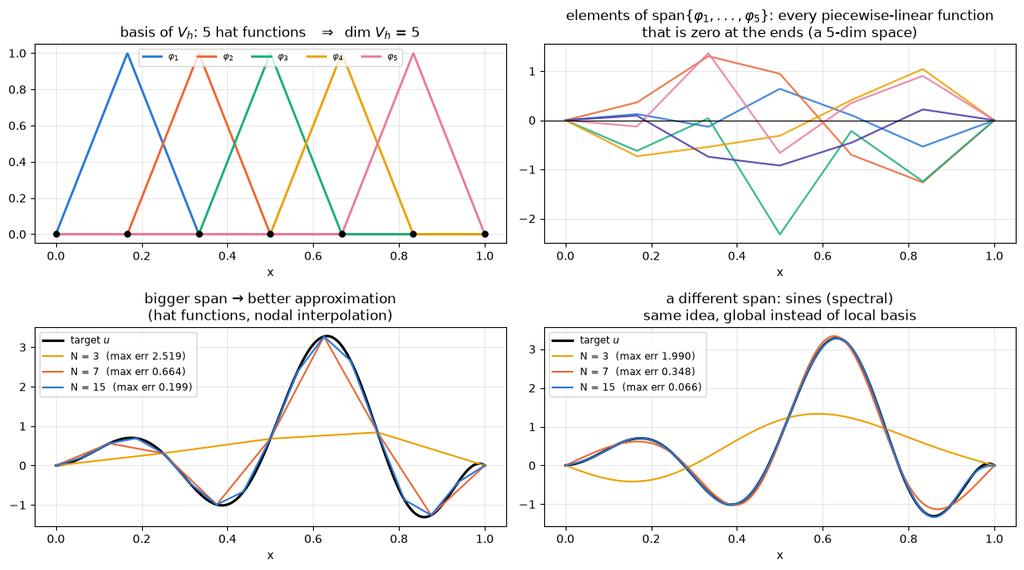

```python
# =============================================================================
# span = ALL linear combinations of the basis functions.
# Two different bases for (approximately) the same job on Omega = (0,1), u(0)=u(1)=0
# =============================================================================
xx = np.linspace(0, 1, 1000)

# ---- basis 1: hat functions on a mesh (finite elements) ---------------------
def hats(N):
    """N interior nodes -> N hat functions, dim V_h = N"""
    nodes = np.linspace(0, 1, N + 2)              # includes the two boundary nodes
    h = nodes[1] - nodes[0]
    def phi(j, x):                                # j = 1..N  (interior nodes only)
        return np.maximum(0.0, 1 - np.abs(x - nodes[j]) / h)
    return nodes, h, phi

# ---- basis 2: sines (spectral) ---------------------------------------------
def sine(k, x):
    return np.sin(k * np.pi * x)

N = 5
nodes, h, phi = hats(N)

fig, ax = plt.subplots(2, 2, figsize=(12.5, 7))
C = ["#2a78d6", "#eb6834", "#1baf7a", "#eda100", "#e87ba4"]

# --- (a) the hat basis --------------------------------------------------------
for j in range(1, N + 1):
    ax[0,0].plot(xx, phi(j, xx), color=C[j-1], lw=2, label=rf"$\varphi_{j}$")
ax[0,0].plot(nodes, 0*nodes, "o", color="k", ms=5)
ax[0,0].set_title(rf"basis of $V_h$: {N} hat functions   $\Rightarrow$  dim $V_h$ = {N}")
ax[0,0].legend(ncol=5, fontsize=8); ax[0,0].grid(alpha=0.3); ax[0,0].set_xlabel("x")

# --- (b) elements of the span = random linear combinations -------------------
rng = np.random.default_rng(0)
for k in range(6):
    c = rng.normal(size=N)
    v = sum(c[j-1] * phi(j, xx) for j in range(1, N + 1))
    ax[0,1].plot(xx, v, lw=1.6, alpha=0.85, color=C[k % 5] if k < 5 else "#4a3aa7")
ax[0,1].axhline(0, color="k", lw=0.8)
ax[0,1].set_title(r"elements of span$\{\varphi_1,...,\varphi_5\}$: every piecewise-linear function"  "\n"  "that is zero at the ends (a 5-dim space)")
ax[0,1].grid(alpha=0.3); ax[0,1].set_xlabel("x")

# --- (c) approximating a target function in spans of growing dimension -------
u = lambda x: x * (1 - x) * np.exp(2 * x) * (1 + 3 * np.sin(4 * np.pi * x))   # target, zero at both ends
ax[1,0].plot(xx, u(xx), "k-", lw=2.2, label="target $u$")
for N_, c in [(3, "#eda100"), (7, "#eb6834"), (15, "#2a78d6")]:
    nodes_, h_, phi_ = hats(N_)
    coef = u(nodes_[1:-1])                                   # interpolation: coefficient = nodal value
    v = sum(coef[j-1] * phi_(j, xx) for j in range(1, N_ + 1))
    err = np.abs(u(xx) - v).max()
    ax[1,0].plot(xx, v, color=c, lw=1.5, label=f"N = {N_}  (max err {err:.3f})")
ax[1,0].set_title("bigger span → better approximation\n(hat functions, nodal interpolation)")
ax[1,0].legend(fontsize=8.5); ax[1,0].grid(alpha=0.3); ax[1,0].set_xlabel("x")

# --- (d) same target, sine basis: coefficients from the L2 projection --------
ax[1,1].plot(xx, u(xx), "k-", lw=2.2, label="target $u$")
for N_, c in [(3, "#eda100"), (7, "#eb6834"), (15, "#2a78d6")]:
    ks = np.arange(1, N_ + 1)
    coef = np.array([2 * np.trapezoid(u(xx) * sine(k, xx), xx) for k in ks])   # <u, sin k pi x> * 2
    v = sum(coef[i] * sine(k, xx) for i, k in enumerate(ks))
    err = np.abs(u(xx) - v).max()
    ax[1,1].plot(xx, v, color=c, lw=1.5, label=f"N = {N_}  (max err {err:.3f})")
ax[1,1].set_title("a different span: sines (spectral)\nsame idea, global instead of local basis")
ax[1,1].legend(fontsize=8.5); ax[1,1].grid(alpha=0.3); ax[1,1].set_xlabel("x")

plt.tight_layout(); plt.show()
```

Panel (b) is what "span" *means*: six random coefficient vectors give six different functions, and every piecewise-linear function vanishing at the ends lives in that 5-dimensional space — nothing else does. Panels (c), (d): a bigger span sits closer to the target, and a *different* span (sines) does the same job with a different trade-off.

```python
# Galerkin: choosing a span turns the PDE into  A u = b
#   -u'' = f on (0,1), u(0)=u(1)=0,  a(u,v) = int u' v',  l(v) = int f v
#   with hat functions:  A = (1/h) tridiag(-1, 2, -1)
# =============================================================================
def galerkin_hats(N, f):
    nodes = np.linspace(0, 1, N + 2); h = nodes[1] - nodes[0]
    A = (np.diag(2*np.ones(N)) + np.diag(-np.ones(N-1), 1) + np.diag(-np.ones(N-1), -1)) / h
    b = f(nodes[1:-1]) * h                                   # simple midpoint/lumped load vector
    return nodes, h, np.linalg.solve(A, b)

f = lambda x: np.pi**2 * np.sin(np.pi * x)                   # exact solution u = sin(pi x)
print("Galerkin with hat functions,  -u'' = pi^2 sin(pi x):")
print(f"{'N':>4} {'dim V_h':>8} {'max nodal error':>16}")
for N_ in [3, 7, 15, 31, 63]:
    nodes, h_, u_h = galerkin_hats(N_, f)
    err = np.abs(u_h - np.sin(np.pi * nodes[1:-1])).max()
    print(f"{N_:>4} {N_:>8} {err:>16.2e}")
```

```
Galerkin with hat functions,  -u'' = pi^2 sin(pi x):
   N  dim V_h  max nodal error
   3        3         5.30e-02
   7        7         1.30e-02
  15       15         3.22e-03
  31       31         8.04e-04
  63       63         2.01e-04
```

## 3. Basic steps — and the order we tackle them (slide 60)

Four questions:

1. How to choose the finite element space $V_h$?
2. How to choose the basis functions $\varphi_i$?
3. How to compute the required integrals?
4. How to solve the linear system?

**We proceed in reverse order:** computing integrals → define basis functions → define finite element space. (Solving the linear system is postponed to Friday.)

Why backwards? Because the *need to compute integrals cheaply* is what dictates which basis functions to choose, and the basis functions in turn define the space. The requirement drives the design.

## 4. Computing integrals → mesh generation (slides 61–62)

We must compute

$$a(\varphi_j,\varphi_i) = \int_\Omega (A\nabla\varphi_j)\cdot\nabla\varphi_i\,dx, \qquad \ell(\varphi_i) = \int_\Omega f\,\varphi_i\,dx$$

To do that we **subdivide $\Omega$** into open subdomains $\omega_k$ of simple shape (triangles, quadrilaterals, tetrahedra, hexahedra, prisms):

$$\bigcup_{k=1}^{M}\overline{\omega_k} = \overline{\Omega}, \qquad \omega_k \cap \omega_l = \emptyset \ \text{ if } k \neq l, \qquad \mathbb{T}_h = \{\omega_1,\dots,\omega_M\}$$

This is the **mesh generation problem** — a separate, complicated problem, done by its own program. Then the integral splits into a sum over elements:

$$a(\varphi_j,\varphi_i) = \int_\Omega (A\nabla\varphi_j)\cdot\nabla\varphi_i\,dx = \sum_{k=1}^{M} \int_{\omega_k} (A\nabla\varphi_j)\cdot\nabla\varphi_i\,dx$$

### Excursion: mesh generation

- A separate and complicated problem in itself; excellent open-source software: **gmsh** (gmsh.info)
- **Conforming mesh:** the intersection of two triangles is a common edge, a common vertex, or empty. (No "hanging nodes" — this is what later makes the basis functions continuous.)
- Geometry described **bottom-up** by boundary representation (BREP): points → lines → line loops → surfaces.

```
lc = 0.1;
Point(1) = {0, 0, 0, lc};      Point(2) = {1, 0, 0, lc};
Point(3) = {1, 1, 0, lc};      Point(4) = {0, 1, 0, lc};
Line(1) = {1,2};  Line(2) = {2,3};  Line(3) = {3,4};  Line(4) = {4,1};
Line Loop(100) = {1,2,3,4};
Plane Surface(200) = {100};
```

Below we build two simple meshes by hand instead (a structured square and an L-shape) so the notebook stays self-contained.

```python
# =============================================================================
# STEP 3a — MESH GENERATION: subdivide Omega into simple shapes
# =============================================================================
def unit_square_mesh(n):
    """structured triangulation of (0,1)^2: n x n squares, each split into 2 triangles"""
    x = np.linspace(0, 1, n + 1)
    X, Y = np.meshgrid(x, x)
    pts = np.column_stack([X.ravel(), Y.ravel()])
    tri = []
    for j in range(n):
        for i in range(n):
            k = lambda jj, ii: jj * (n + 1) + ii
            tri += [[k(j, i), k(j, i+1), k(j+1, i+1)], [k(j, i), k(j+1, i+1), k(j+1, i)]]
    return pts, np.array(tri)

def lshape_mesh(n):
    """L-shaped domain: the unit square minus its upper-right quadrant (re-entrant corner at (0.5,0.5))"""
    pts, tri = unit_square_mesh(n)
    c = pts[tri].mean(axis=1)
    keep = ~((c[:, 0] > 0.5) & (c[:, 1] > 0.5))
    tri = tri[keep]
    used = np.unique(tri)                              # drop unused vertices and renumber
    remap = -np.ones(len(pts), int); remap[used] = np.arange(len(used))
    return pts[used], remap[tri]
```

## 5. Introducing the finite element space $V_h$ — "bottom-up" (slide 63)

There are many ways to introduce finite element functions; all of them use the mesh. The **bottom-up** approach taken here has four steps:

1. Introduce the **reference element**
2. Define **(basis) functions on the reference element**
3. **Transform** from reference element to general element
4. **Element-by-element combination** into global basis functions

The reason for this detour: we do *not* want to derive a formula for every triangle in the mesh. We define the functions **once** on one standard triangle and map them everywhere.

### 5.1 Basis functions on the reference element (slide 64)

Reference element (triangle):

$$\hat\omega = \{(\hat x_1, \hat x_2) : \hat x_1 > 0 \ \wedge\ \hat x_2 > 0 \ \wedge\ \hat x_1 + \hat x_2 < 1\}$$

with vertices $\hat x^1 = (0,0)^T$, $\hat x^2 = (1,0)^T$, $\hat x^3 = (0,1)^T$, and the three linear basis functions

$$\hat\varphi_1(\hat x) = 1 - \hat x_1 - \hat x_2, \qquad \hat\varphi_2(\hat x) = \hat x_1, \qquad \hat\varphi_3(\hat x) = \hat x_2$$

**Kronecker property:** $\hat\varphi_i(\hat x^j) = \delta_{ij}$ — each basis function is 1 at "its own" vertex and 0 at the other two. This is what makes the coefficients meaningful: $z_j$ is simply *the value of the solution at vertex $j$*.

```python
# STEP 2 — BASIS FUNCTIONS ON THE REFERENCE ELEMENT
#   reference triangle T_hat with vertices (0,0), (1,0), (0,1)
#   P1 basis:  N1 = 1 - xi - eta,  N2 = xi,  N3 = eta      (N_i(node_j) = delta_ij)
# =============================================================================
N_hat      = [lambda xi, et: 1 - xi - et, lambda xi, et: xi, lambda xi, et: et]
grad_N_hat = np.array([[-1.0, -1.0], [1.0, 0.0], [0.0, 1.0]])     # constant for P1

# affine map  F(xi) = B xi + p1  from T_hat onto the physical triangle
def affine(p):                       # p = 3x2 array of the triangle's vertices
    B = np.column_stack([p[1] - p[0], p[2] - p[0]])
    return B, p[0], np.linalg.det(B)

# quadrature on T_hat: 3-point rule, exact for quadratics, weights sum to |T_hat| = 1/2
QP = np.array([[1/6, 1/6], [2/3, 1/6], [1/6, 2/3]]); QW = np.array([1/6, 1/6, 1/6])
```

### 5.2 Transformation to a general element (slides 65 and 67)

Associate the reference element with an arbitrary triangle $\omega_k$ whose vertices are $x^\alpha, x^\beta, x^\gamma$. The **local-to-global map** records which global vertex each local corner is: $g(k,1) = \alpha$, $g(k,2) = \beta$, $g(k,3) = \gamma$.

The **map** $\hat\mu_k : \hat\omega \to \omega_k$ is affine for triangles:

$$\hat\mu_k(\hat x) = B_k \hat x + b_k, \qquad B_k = [\,x^\beta - x^\alpha,\ x^\gamma - x^\alpha\,] \in \mathbb{R}^{2\times2}, \qquad b_k = x^\alpha$$

Basis functions on the transformed element are just the reference ones, pulled back:

$$\varphi_{g(k,i)}(x) = \hat\varphi_i(\hat\mu_k^{-1}(x)) \qquad\Longleftrightarrow\qquad \varphi_{g(k,i)}(\hat\mu_k(\hat x)) = \hat\varphi_i(\hat x)$$

**Two transformation rules do all the work** (slide 67). By the chain rule, gradients transform as

$$\nabla u(\hat\mu_k(\hat x)) = \big(\hat\nabla\hat\mu_k(\hat x)\big)^{-T}\,\hat\nabla\hat u(\hat x) \;=\; B_k^{-T}\,\hat\nabla\hat u(\hat x)$$

and integrals transform with the Jacobian determinant

$$\int_{\omega_k} f(x)\,dx = \int_{\hat\omega} f(\hat\mu_k(\hat x))\,\big|\det \hat\nabla\hat\mu_k(\hat x)\big|\,d\hat x = |\det B_k| \int_{\hat\omega} f(\hat\mu_k(\hat x))\,d\hat x$$

Putting both together, the element contribution to the stiffness matrix is

$$\int_{\omega_k}\nabla\varphi_j\cdot\nabla\varphi_i\,dx = |\det B_k|\int_{\hat\omega}\big(B_k^{-T}\hat\nabla\hat\varphi_j\big)\cdot\big(B_k^{-T}\hat\nabla\hat\varphi_i\big)\,d\hat x$$

**Everything is computed on $\hat\omega$.** The geometry of an element enters only through the $2\times2$ matrix $B_k$ — that is why FEM codes are short and fast.

### 5.3 Element-by-element construction (slide 66)

"Global" basis functions are defined element by element. For the vertex $\alpha$ at position $x^\alpha$:

$$\varphi_\alpha(x) = \hat\varphi_i(\hat x) \quad\text{where}\quad x = \mu_k(\hat x) \ \wedge\ g(k,i) = \alpha$$

i.e. on each element touching vertex $\alpha$, use whichever local basis function belongs to that vertex; elsewhere $\varphi_\alpha = 0$. Consequences:

- $\varphi_\alpha(x^\beta) = \delta_{\alpha\beta}$ — the global Kronecker property,
- basis functions are nonzero only on very few elements: they have **local support** → the matrix $A$ is **sparse**,
- the $\varphi_i$ are **continuous** (because the mesh is conforming) → $V_h \subset H^1_0(\Omega)$ really holds,
- $V_h = \operatorname{span}\{\varphi_1,\dots,\varphi_N\}$ where $N$ is the number of **interior** vertices (boundary vertices are excluded because $u = 0$ there).

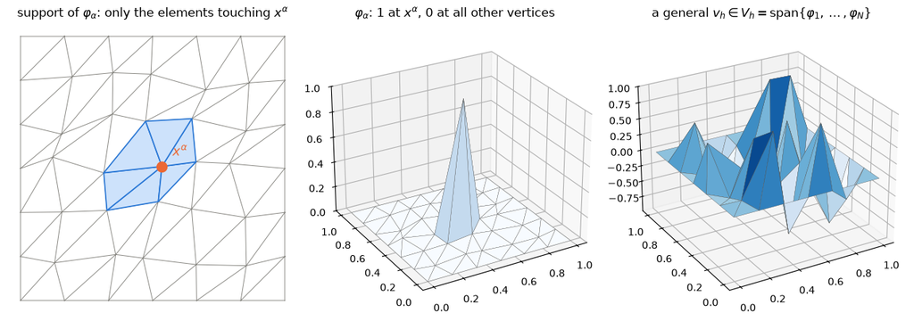

```
mesh: 49 vertices, 72 triangles
phi_alpha is nonzero on only 6 of 72 elements  ->  LOCAL SUPPORT
N = dim V_h = number of INTERIOR vertices = 25
```

```python
def square_mesh(n):
    x = np.linspace(0, 1, n + 1); X, Y = np.meshgrid(x, x)
    pts = np.column_stack([X.ravel(), Y.ravel()]); tri = []
    for j in range(n):
        for i in range(n):
            k = lambda jj, ii: jj*(n+1) + ii
            tri += [[k(j,i), k(j,i+1), k(j+1,i+1)], [k(j,i), k(j+1,i+1), k(j+1,i)]]
    return pts, np.array(tri)

pts, tri = square_mesh(6)
rng = np.random.default_rng(3)                       # jiggle interior nodes -> unstructured look
interior = (pts[:,0] > 1e-9) & (pts[:,0] < 1-1e-9) & (pts[:,1] > 1e-9) & (pts[:,1] < 1-1e-9)
pts[interior] += rng.uniform(-0.045, 0.045, pts[interior].shape)

alpha = np.argmin(np.hypot(pts[:,0] - 0.5, pts[:,1] - 0.5))     # the vertex we build phi_alpha for
support = np.array([k for k, t in enumerate(tri) if alpha in t]) # elements touching it

fig = plt.figure(figsize=(12.5, 4.6), constrained_layout=True)
T = mtri.Triangulation(pts[:,0], pts[:,1], tri)

ax1 = fig.add_subplot(1, 3, 1)
ax1.triplot(T, color="#8a8984", lw=0.7)
for k in support:
    ax1.add_patch(plt.Polygon(pts[tri[k]], fc="#cde2fb", ec="#2a78d6", lw=1.2))
ax1.plot(*pts[alpha], "o", color="#eb6834", ms=10, zorder=5)
ax1.annotate(r"$x^\alpha$", pts[alpha], pts[alpha] + [0.04, 0.04], fontsize=13, color="#eb6834")
ax1.set_title(r"support of $\varphi_\alpha$: only the elements touching $x^\alpha$")
ax1.set_aspect("equal"); ax1.axis("off")

ax2 = fig.add_subplot(1, 3, 2, projection="3d")
z = np.zeros(len(pts)); z[alpha] = 1.0
ax2.plot_trisurf(T, z, cmap="Blues", edgecolor="#52514e", linewidth=0.25, vmin=0, vmax=1.3)
ax2.set_title(r"$\varphi_\alpha$: 1 at $x^\alpha$, 0 at all other vertices")
ax2.set_zlim(0, 1); ax2.view_init(26, -120)

ax3 = fig.add_subplot(1, 3, 3, projection="3d")
rng2 = np.random.default_rng(1)
z2 = np.zeros(len(pts)); z2[interior] = rng2.uniform(-1, 1, interior.sum())
ax3.plot_trisurf(T, z2, cmap="Blues", edgecolor="#52514e", linewidth=0.25)
ax3.set_title(r"a general $v_h \in V_h = \mathrm{span}\{\varphi_1,\dots,\varphi_N\}$")
ax3.view_init(26, -120)
plt.show()

print(f"mesh: {len(pts)} vertices, {len(tri)} triangles")
print(f"phi_alpha is nonzero on only {len(support)} of {len(tri)} elements  ->  LOCAL SUPPORT")
print(f"N = dim V_h = number of INTERIOR vertices = {interior.sum()}")
```

## 6. Putting it together: assemble and solve

The loop below **is** the finite element method. Note there is no `if` for element shape or position — every triangle is handled by the same three lines, differing only through $B_k$.

```python
# STEP 3b — COMPUTE THE INTEGRALS, element by element, all on T_hat
#   a(phi_j, phi_i) = sum_K int_K grad phi_j . grad phi_i dx
#                   = sum_K |det B| int_That (B^-T grad N_j).(B^-T grad N_i) d xi
# =============================================================================
def assemble(pts, tri, f):
    n = len(pts)
    A = np.zeros((n, n)); b = np.zeros(n)
    for t in tri:
        p = pts[t]
        B, p0, detB = affine(p)
        Binv_T = np.linalg.inv(B).T
        G = grad_N_hat @ Binv_T.T                       # physical gradients, 3x2 (constant on K)
        A[np.ix_(t, t)] += abs(detB) * 0.5 * (G @ G.T)  # int over T_hat of a constant = area 1/2
        for (xi, et), w in zip(QP, QW):                 # load vector by quadrature
            xq = B @ np.array([xi, et]) + p0
            b[t] += w * abs(detB) * f(*xq) * np.array([Nh(xi, et) for Nh in N_hat])
    return A, b
```

```python
# STEP 4 — SOLVE THE LINEAR SYSTEM  (Dirichlet u = 0 on the boundary)
# =============================================================================
def solve(pts, tri, f, on_boundary):
    A, b = assemble(pts, tri, f)
    bnd = on_boundary(pts)
    free = ~bnd
    u = np.zeros(len(pts))
    u[free] = np.linalg.solve(A[np.ix_(free, free)], b[free])
    return u

# ---- verification: -Delta u = 2 pi^2 sin(pi x) sin(pi y), exact u = sin sin ----
f_test = lambda x, y: 2 * np.pi**2 * np.sin(np.pi * x) * np.sin(np.pi * y)
u_test = lambda x, y: np.sin(np.pi * x) * np.sin(np.pi * y)
sq_bnd = lambda p: (p[:, 0] <= 1e-12) | (p[:, 0] >= 1 - 1e-12) | (p[:, 1] <= 1e-12) | (p[:, 1] >= 1 - 1e-12)

print("FEM on the unit square,  -Laplace u = 2*pi^2 sin(pi x) sin(pi y)")
print(f"{'n':>4} {'triangles':>10} {'unknowns':>9} {'max error':>11} {'ratio':>7}")
prev = None
for n in [4, 8, 16, 32]:
    pts, tri = unit_square_mesh(n)
    u = solve(pts, tri, f_test, sq_bnd)
    err = np.abs(u - u_test(pts[:, 0], pts[:, 1])).max()
    print(f"{n:>4} {len(tri):>10} {(~sq_bnd(pts)).sum():>9} {err:>11.3e} {'' if prev is None else f'{prev/err:7.2f}'}")
    prev = err
```

```
FEM on the unit square,  -Laplace u = 2*pi^2 sin(pi x) sin(pi y)
   n  triangles  unknowns   max error   ratio
   4         32         9   4.890e-02
   8        128        49   1.269e-02    3.85
  16        512       225   3.203e-03    3.96
  32       2048       961   8.026e-04    3.99
```

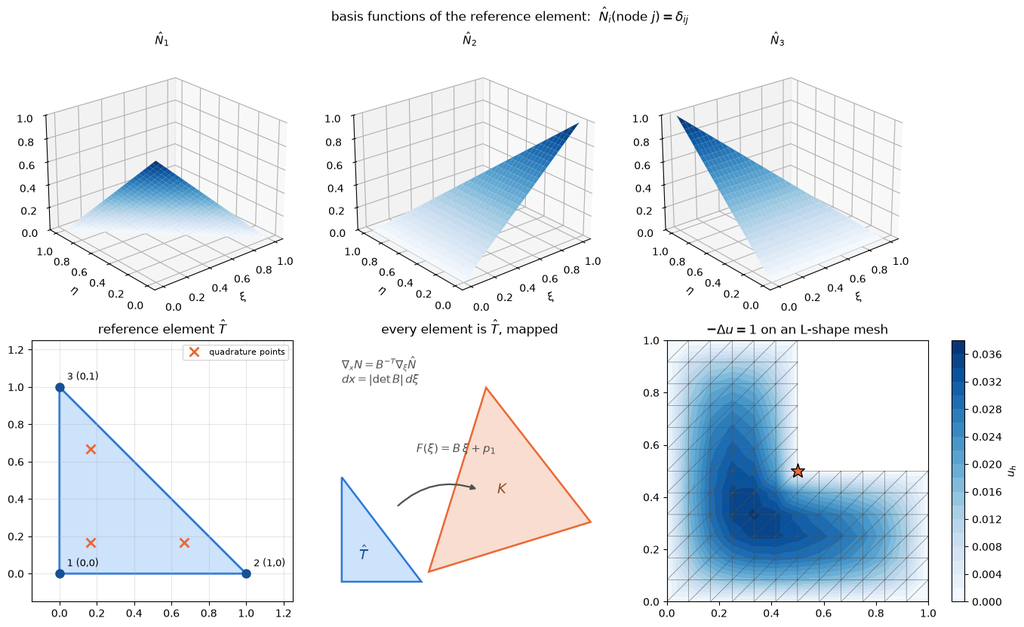

```python
fig = plt.figure(figsize=(13.5, 8.2), constrained_layout=True)
gs = fig.add_gridspec(2, 3)

# --- top row: the three basis functions on the reference element -------------
xi = np.linspace(0, 1, 60); Xi, Et = np.meshgrid(xi, xi); mask = Xi + Et > 1
for k in range(3):
    ax = fig.add_subplot(gs[0, k], projection="3d")
    Z = np.where(mask, np.nan, N_hat[k](Xi, Et))
    ax.plot_surface(Xi, Et, Z, cmap="Blues", edgecolor="none", vmin=0, vmax=1)
    ax.set_title(rf"$\hat{{N}}_{k+1}$", fontsize=11)
    ax.set_xlabel(r"$\xi$"); ax.set_ylabel(r"$\eta$"); ax.set_zlim(0, 1); ax.view_init(24, -130)
fig.suptitle(r"basis functions of the reference element:  $\hat N_i(\mathrm{node}\ j) = \delta_{ij}$", fontsize=12)

# --- (a) reference element with quadrature points ----------------------------
axr = fig.add_subplot(gs[1, 0])
axr.add_patch(plt.Polygon([[0, 0], [1, 0], [0, 1]], fc="#cde2fb", ec="#2a78d6", lw=2))
for (a_, b_), lab in zip([[0, 0], [1, 0], [0, 1]], ["1 (0,0)", "2 (1,0)", "3 (0,1)"]):
    axr.plot(a_, b_, "o", color="#184f95", ms=8); axr.annotate(lab, (a_, b_), (a_ + 0.04, b_ + 0.04), fontsize=9)
axr.plot(*QP.T, "x", color="#eb6834", ms=8, mew=2, label="quadrature points")
axr.set_title(r"reference element $\hat{T}$"); axr.set_aspect("equal")
axr.set_xlim(-0.15, 1.25); axr.set_ylim(-0.15, 1.25); axr.legend(fontsize=8, loc="upper right"); axr.grid(alpha=0.3)

# --- (b) the affine map onto a physical element ------------------------------
axm = fig.add_subplot(gs[1, 1])
p_phys = np.array([[0.35, 0.12], [1.0, 0.32], [0.58, 0.86]])
axm.add_patch(plt.Polygon([[0.0, 0.08], [0.32, 0.08], [0.0, 0.5]], fc="#cde2fb", ec="#2a78d6", lw=1.8))
axm.text(0.07, 0.17, r"$\hat{T}$", fontsize=13, color="#184f95")
axm.add_patch(plt.Polygon(p_phys, fc="#f8ddd0", ec="#eb6834", lw=1.8))
axm.text(*p_phys.mean(axis=0), r"$K$", fontsize=13, color="#8a4b1f", ha="center")
axm.annotate("", xy=(0.55, 0.45), xytext=(0.22, 0.38),
             arrowprops=dict(arrowstyle="-|>", color="#52514e", lw=1.6, connectionstyle="arc3,rad=-0.3"))
axm.text(0.30, 0.60, r"$F(\xi) = B\,\xi + p_1$", fontsize=11, color="#52514e")
axm.text(0.0, 0.99, r"$\nabla_x N = B^{-T}\nabla_\xi \hat{N}$" "\n" r"$dx = |\det B|\, d\xi$",
         fontsize=10.5, color="#52514e", va="top")
axm.set_xlim(-0.05, 1.08); axm.set_ylim(0.0, 1.05); axm.set_aspect("equal"); axm.axis("off")
axm.set_title("every element is $\\hat{T}$, mapped")

# --- (c) mesh + solution on the L-shape --------------------------------------
axs = fig.add_subplot(gs[1, 2])
pts, tri = lshape_mesh(12)
u = solve(pts, tri, lambda x, y: 1.0, lambda p: np.array([
    (abs(q[0]) < 1e-12) | (abs(q[1]) < 1e-12) | (abs(q[0] - 1) < 1e-12) | (abs(q[1] - 1) < 1e-12) |
    ((abs(q[0] - 0.5) < 1e-12) & (q[1] >= 0.5 - 1e-12)) | ((abs(q[1] - 0.5) < 1e-12) & (q[0] >= 0.5 - 1e-12))
    for q in p]))
T = mtri.Triangulation(pts[:, 0], pts[:, 1], tri)
cf = axs.tricontourf(T, u, levels=18, cmap="Blues")
axs.triplot(T, color="#52514e", lw=0.35)
fig.colorbar(cf, ax=axs, fraction=0.046, label="$u_h$")
axs.plot(0.5, 0.5, "*", color="#eb6834", ms=14, mec="k")
axs.set_title(r"$-\Delta u = 1$ on an L-shape mesh"); axs.set_aspect("equal")
plt.show()
```

The convergence test on the unit square: the error drops by a factor **4** each time the mesh is halved — $O(h^2)$ in the max norm, exactly what the theory in Section 8 predicts for $p = 1$ with a smooth solution.

## 7. Generalization (slide 68)

The same procedure generalizes to:

- **simplices of dimension $d > 2$** (tetrahedra in 3-D),
- **other element types**: quadrilaterals, hexahedra, prisms,
- **higher-order polynomials $p > 1$** per element (more nodes per element → more basis functions),
- **elements with curved boundaries** ⇒ objects with **smooth surfaces** can be handled (the map $\hat\mu_k$ is then no longer affine).

This flexibility explains the popularity of the finite element method.

**But:** $N$ increases exponentially in $d$ — the **curse of dimension**. A mesh with $n$ cells per direction has $n^d$ elements: $n = 100$ gives $10^4$ in 2-D but $10^6$ in 3-D.

## 8. The finite element error (slides 71–73)

The exact and the discrete solution satisfy *the same equation*, on different spaces:

$$u \in H^1_0(\Omega): \quad a(u,v) = \ell(v) \ \ \forall v \in H^1_0(\Omega)$$ $$u_h \in V_h: \quad a(u_h,v) = \ell(v) \ \ \forall v \in V_h$$

The **finite element error** is $e = u - u_h \in H^1_0(\Omega)$.

### Céa's lemma — the key estimate

$$\|u - u_h\|_{1,\Omega} \le \frac{C_a}{\alpha} \min_{v_h \in V_h} \|u - v_h\|_{1,\Omega}$$

where $\alpha$ (coercivity) and $C_a$ (continuity) are the Lax–Milgram constants.

**In words:** the FEM solution is, up to a constant, *as good as the best approximation available in $V_h$*. Galerkin never does much worse than the space allows. So the error question becomes a pure **approximation theory** question: how well can piecewise polynomials approximate $u$?

To bound the minimum, pick any convenient $v_h$ — the **finite element interpolant** $I_h(u) \in V_h$, defined by $I_h(u)(x^j) = u(x^j)$ at all mesh vertices:

$$\min_{v_h\in V_h}\|u - v_h\|_{1,\Omega} \le \|u - I_h(u)\|_{1,\Omega}$$

### The a priori estimate

Careful: $I_h(u)$ needs point values, so it requires $u \in H^2$ — $u \in H^1_0$ is **not** sufficient. Assuming $u \in H^s_0(\Omega)$ for some $s > 1$ (a **regularity assumption**), with polynomial degree $p \ge 1$ and maximum element diameter $h$:

$$\boxed{\ \|u - u_h\|_{1,\Omega} \le C\,h^{\min(s-1,\,p)}\ } \qquad\qquad \|u - u_h\|_{0,\Omega} \le C\,h^{\min(s,\,p+1)}$$

**Convergence order depends on three things: polynomial degree $p$, regularity $s$, and the norm.** Raising $p$ helps only if $u$ is smooth enough to deserve it — and Monday's re-entrant corner is precisely the case where $s$ is small and no polynomial degree can save you.

## 9. Properties of the linear system (slide 74)

- $A$ has **many zero entries** — because basis functions have local support. For fixed polynomial degree, $\mathrm{nonzeros}(A) \le CN$ under mesh refinement: the work per unknown stays constant.
- **Symmetry** of $a(\cdot,\cdot)$ ⟹ $A$ is symmetric.
- **Coercivity** of $a(\cdot,\cdot)$ ⟹ $A$ is positive definite. (So conjugate gradients applies.)
- Asymptotically the error decreases as the mesh — and hence the size of $A$ — grows.
- **Computational effort in FEM is dominated by solving the linear system** (slide 75: for $N \approx 6\times10^6$ in 2-D, assembly takes 2.7 s but the sparse direct solver takes 61 s; a CG solver with algebraic multigrid takes 16 s — and scales far better).

Let's verify all three matrix properties numerically.

```python
# ---------------------------------------------------------------- reference element (slide 64)
grad_phi_hat = np.array([[-1.0, -1.0], [1.0, 0.0], [0.0, 1.0]])
phi_hat = [lambda a, b: 1 - a - b, lambda a, b: a, lambda a, b: b]
# 6-point quadrature on the reference triangle, exact for degree 4 (weights sum to 1/2)
_a, _b = 0.445948490915965, 0.091576213509771
QP = np.array([[_a,_a],[1-2*_a,_a],[_a,1-2*_a],[_b,_b],[1-2*_b,_b],[_b,1-2*_b]])
QW = np.array([0.111690794839005]*3 + [0.054975871827661]*3)

def lshape_mesh(n):
    """(-1,1)^2 minus (0,1)x(-1,0); re-entrant corner at the origin, interior angle 3*pi/2"""
    x = np.linspace(-1, 1, 2*n + 1)
    X, Y = np.meshgrid(x, x)
    pts = np.column_stack([X.ravel(), Y.ravel()]); m = 2*n + 1
    tri = []
    for j in range(2*n):
        for i in range(2*n):
            k = lambda jj, ii: jj*m + ii
            tri += [[k(j,i), k(j,i+1), k(j+1,i+1)], [k(j,i), k(j+1,i+1), k(j+1,i)]]
    tri = np.array(tri)
    c = pts[tri].mean(axis=1)
    tri = tri[~((c[:,0] > 0) & (c[:,1] < 0))]
    used = np.unique(tri); remap = -np.ones(len(pts), int); remap[used] = np.arange(len(used))
    return pts[used], remap[tri], 1.0/n              # h = element size

# exact singular solution:  u = r^(2/3) sin(2*theta/3),  Delta u = 0
def u_ex(p):
    r = np.hypot(p[:,0], p[:,1]); th = np.mod(np.arctan2(p[:,1], p[:,0]), 2*np.pi)
    return np.where(r < 1e-15, 0.0, r**(2/3) * np.sin(2*th/3))
def grad_u_ex(p):
    r = np.hypot(p[:,0], p[:,1]); th = np.mod(np.arctan2(p[:,1], p[:,0]), 2*np.pi)
    r = np.maximum(r, 1e-14)
    ur = (2/3)*r**(-1/3)*np.sin(2*th/3); ut = (2/3)*r**(-1/3)*np.cos(2*th/3)
    return np.column_stack([ur*np.cos(th) - ut*np.sin(th), ur*np.sin(th) + ut*np.cos(th)])

def solve_and_errors(n):
    pts, tri, h = lshape_mesh(n)
    N = len(pts)
    rows, cols, vals = [], [], []
    for t in tri:
        p = pts[t]; B = np.column_stack([p[1]-p[0], p[2]-p[0]]); detB = np.linalg.det(B)
        G = grad_phi_hat @ np.linalg.inv(B)                  # physical gradients (3x2)
        Ke = abs(detB) * 0.5 * (G @ G.T)
        rows += list(np.repeat(t, 3)); cols += list(np.tile(t, 3)); vals += list(Ke.ravel())
    A = sp.csr_matrix((vals, (rows, cols)), shape=(N, N))
    b = np.zeros(N)                                          # f = 0 (u is harmonic)
    bnd = (np.abs(np.abs(pts[:,0]) - 1) < 1e-12) | (np.abs(np.abs(pts[:,1]) - 1) < 1e-12) | \
          ((np.abs(pts[:,1]) < 1e-12) & (pts[:,0] >= -1e-12)) | ((np.abs(pts[:,0]) < 1e-12) & (pts[:,1] <= 1e-12))
    g = u_ex(pts)
    u = np.zeros(N); u[bnd] = g[bnd]
    free = ~bnd
    u[free] = spla.spsolve(A[free][:, free].tocsc(), (b - A @ u)[free])

    # errors by quadrature on each element
    e0 = e1 = 0.0
    for t in tri:
        p = pts[t]; B = np.column_stack([p[1]-p[0], p[2]-p[0]]); detB = abs(np.linalg.det(B))
        G = grad_phi_hat @ np.linalg.inv(B)
        grad_uh = u[t] @ G                                   # constant on the element
        xq = (B @ QP.T).T + p[0]
        uh_q = sum(u[t][i] * phi_hat[i](QP[:,0], QP[:,1]) for i in range(3))
        e0 += detB * np.sum(QW * (u_ex(xq) - uh_q)**2)
        e1 += detB * np.sum(QW * np.sum((grad_u_ex(xq) - grad_uh)**2, axis=1))
    return N, free.sum(), h, np.sqrt(e0), np.sqrt(e1), A
```

```python
# ---------------------------------------------------------------- properties of A (slide 74)
print("\nProperties of the matrix A (slide 74):")
print(f"{'unknowns N':>11} {'nonzeros':>10} {'nnz/N':>7} {'symmetric':>10} {'min eigenvalue':>15}")
for n in [2, 4, 8, 16]:
    Ntot, nfree, h, e0, e1, A = solve_and_errors(n)
    pts, tri, _ = lshape_mesh(n)
    bnd = (np.abs(np.abs(pts[:,0]) - 1) < 1e-12) | (np.abs(np.abs(pts[:,1]) - 1) < 1e-12) | \
          ((np.abs(pts[:,1]) < 1e-12) & (pts[:,0] >= -1e-12)) | ((np.abs(pts[:,0]) < 1e-12) & (pts[:,1] <= 1e-12))
    Af = A[~bnd][:, ~bnd].toarray()
    ev = np.linalg.eigvalsh(Af)
    print(f"{len(Af):>11} {int((Af != 0).sum()):>10} {(Af != 0).sum()/len(Af):>7.2f} "
          f"{str(np.allclose(Af, Af.T)):>10} {ev.min():>15.4e}")
```

```
Properties of the matrix A (slide 74):
 unknowns N   nonzeros   nnz/N  symmetric  min eigenvalue
          5         13    2.60       True      2.2679e+00
         33        137    4.15       True      6.0259e-01
        161        745    4.63       True      1.5146e-01
        705       3401    4.82       True      3.7787e-02
```

`nnz/N` levels off around 5 — each row has a bounded number of entries no matter how fine the mesh, because each vertex has a bounded number of neighbours. `symmetric = True` and `min eigenvalue > 0` confirm symmetry and positive definiteness. Note the smallest eigenvalue *shrinks* under refinement ($\propto h^2$): the condition number grows like $h^{-2}$, which is why solving the system — not assembling it — is the expensive part, and why preconditioners matter.

## 10. Adaptive mesh refinement (slide 76) — and Monday's re-entrant corner

The last slide shows the **L-shaped domain**: the square with a $270°$ re-entrant corner. The exact solution near such a corner behaves like

$$u \sim r^{\pi/\omega}\sin\!\big(\tfrac{\pi\theta}{\omega}\big), \qquad \omega = \tfrac{3\pi}{2} \Rightarrow \ u \sim r^{2/3}$$

The lecture's table for the uniform mesh reports $H^1$-rate $\approx 0.66$ and $L^2$-rate $\approx 1.32$ — the $H^1$ rate is exactly the predicted $2/3$, and **more refinement does not fix it**, because the limit is the regularity of $u$, not the mesh size.

The cure is **adaptive mesh refinement**: put small elements only where the solution is rough. The lecture's adapted-mesh column recovers $H^1$-rate $\approx 0.9$ with *fewer* unknowns.

Let's reproduce the uniform-mesh half of that table.

```python
print("L-shape, u = r^(2/3) sin(2*theta/3), uniform refinement  (Bastian slide 76)")
print(f"{'N':>8} {'h':>8} {'||u-uh||_0':>12} {'L2-rate':>8} {'|u-uh|_1':>11} {'H1-rate':>8}")
prev = None
for n in [2, 4, 8, 16, 32, 64]:
    Ntot, nfree, h, e0, e1, A = solve_and_errors(n)
    r0 = r1 = ""
    if prev: r0 = f"{np.log(prev[0]/e0)/np.log(2):8.4f}"; r1 = f"{np.log(prev[1]/e1)/np.log(2):8.4f}"
    print(f"{nfree:>8} {h:>8.4f} {e0:>12.4e} {r0:>8} {e1:>11.4e} {r1:>8}")
    prev = (e0, e1)
print(f"\ntheory for a {270}-deg corner: alpha = pi/omega = 2/3  ->  H1 rate {2/3:.4f}, L2 rate {4/3:.4f}")
```

```
L-shape, u = r^(2/3) sin(2*theta/3), uniform refinement  (Bastian slide 76)
       N        h   ||u-uh||_0  L2-rate    |u-uh|_1  H1-rate
       5   0.5000   3.7875e-02           2.8845e-01
      33   0.2500   1.5970e-02   1.2459  1.8694e-01   0.6258
     161   0.1250   6.6193e-03   1.2706  1.2033e-01   0.6356
     705   0.0625   2.7124e-03   1.2871  7.6892e-02   0.6461
    2945   0.0312   1.1022e-03   1.2992  4.8887e-02   0.6534
   12033   0.0156   4.4502e-04   1.3084  3.0978e-02   0.6582

theory for a 270-deg corner: alpha = pi/omega = 2/3  ->  H1 rate 0.6667, L2 rate 1.3333
```

## 11. The typical FEM tool chain (slides 69–70)

$$\boxed{\text{Mesh generation}} \longrightarrow \boxed{\text{FE problem setup and solve}} \longrightarrow \boxed{\text{Visualization of results}}$$

[output not shown]

**Practical session:** tool pipeline with Gmsh, Dune and ParaView — a simple problem with a polynomial solution, the re-entrant corner problem (2-D), and the gravity problem (3-D).

## Day 3 in one table

| slide | question | answer |
| --- | --- | --- |
| 59 | how does a PDE become a matrix? | pick $V_h = \operatorname{span}\{\varphi_i\}$, insert $u_h = \sum_j z_j\varphi_j$, test with each $\varphi_i$ → $A\mathbf{z} = \mathbf{b}$ |
| 61 | how to compute $\int_\Omega$? | split into $\sum_k \int_{\omega_k}$ over mesh elements |
| 64 | which basis functions? | define once on the reference element, with $\hat\varphi_i(\hat x^j) = \delta_{ij}$ |
| 65, 67 | how do they reach a general element? | affine map $\hat\mu_k(\hat x) = B_k\hat x + b_k$; $\nabla u = B_k^{-T}\hat\nabla\hat u$, $dx = \lvert\det B_k\rvert d\hat x$ |
| 66 | what is $V_h$? | glue element-by-element: continuous, locally supported, $N$ = number of interior vertices |
| 72 | how big is the error? | Céa: FEM ≈ best approximation in $V_h$ |
| 73 | how fast does it converge? | $\\|u-u_h\\|_{1} \le Ch^{\min(s-1,p)}$ — degree, regularity, **and** norm |
| 74 | what does $A$ look like? | sparse, symmetric, positive definite; solving it dominates the cost |
| 76 | what if $u$ is not smooth? | uniform refinement stalls at $h^{2/3}$; adapt the mesh instead |